# Lecture 11

Alex Shpenev

4/8/2021

[output not shown]

```r
setwd("~/Desktop/516/W11")
tweets <- read_csv("trump_tweets.csv")
nrc <- read_rds("nrc.rds")
tweets
```

```
## # A tibble: 35,219 x 8
##    source id_str text  created_at          retweet_count in_reply_to_use…
##    <chr>   <dbl> <chr> <dttm>                      <dbl>            <dbl>
##  1 Twitt… 6.97e9 "Fro… 2009-12-23 17:38:18            28               NA
##  2 Twitt… 6.31e9 "Tru… 2009-12-03 19:39:09            33               NA
##  3 Twitt… 6.09e9 "Wis… 2009-11-26 19:55:38            13               NA
##  4 Twitt… 5.78e9 "Don… 2009-11-16 21:06:10             5               NA
##  5 Twitt… 5.36e9 "--W… 2009-11-02 14:57:56             7               NA
##  6 Twitt… 5.20e9 "--F… 2009-10-27 15:31:48             4               NA
##  7 Twitt… 5.07e9 "Hea… 2009-10-22 13:57:04             2               NA
##  8 Twitt… 4.86e9 "Wat… 2009-10-14 14:13:17             4               NA
##  9 Twitt… 4.63e9 "- R… 2009-10-05 14:37:38             1               NA
## 10 Twitt… 4.47e9 "\"A… 2009-09-29 15:28:23            23               NA
## # … with 35,209 more rows, and 2 more variables: favorite_count <dbl>,
## #   is_retweet <lgl>
```

nrc dictionary has 10 sentiment categories

```r
nrc %>%
  group_by(sentiment) %>%
  summarise(n())
```

```
## # A tibble: 10 x 2
##    sentiment    `n()`
##  * <chr>        <int>
##  1 anger         1247
##  2 anticipation   839
##  3 disgust       1058
##  4 fear          1476
##  5 joy            689
##  6 negative      3324
##  7 positive      2312
##  8 sadness       1191
##  9 surprise       534
## 10 trust         1231
```

Listing Trump’s sources of tweets

```r
tweets %>%
  count(source) %>%
  arrange(-n)
```

```
## # A tibble: 19 x 2
##    source                       n
##    <chr>                    <int>
##  1 Twitter for Android      14545
##  2 Twitter Web Client       12179
##  3 Twitter for iPhone        6850
##  4 TweetDeck                  483
##  5 TwitLonger Beta            405
##  6 Media Studio               154
##  7 Instagram                  133
##  8 Facebook                   105
##  9 Twitter Ads                 97
## 10 Twitter for BlackBerry      97
## 11 Twitter for iPad            58
## 12 Mobile Web (M5)             56
## 13 Twitlonger                  23
## 14 Twitter QandA               10
## 15 Vine - Make a Scene         10
## 16 Periscope                    7
## 17 Neatly For BlackBerry 10     5
## 18 Twitter for Websites         1
## 19 Twitter Mirror for iPad      1
```

Creating a dataset to analyze two sources: iPhone and Android “(\w+)$” regular expression used to mark the last word

```r
cleaned_tweets <- tweets %>%
select(id_str, source, text, created_at) %>%
  filter(source %in% c("Twitter for iPhone", "Twitter for Android"))  %>%
  extract(source, "source", "(\\w+)$")
cleaned_tweets
```

```
## # A tibble: 21,395 x 4
##     id_str source  text                                      created_at
##      <dbl> <chr>   <chr>                                     <dttm>
##  1 2.78e17 iPhone  "Good luck to Bob Kraft, Tom Brady, and … 2012-12-11 01:20:01
##  2 4.18e17 Android "Have a happy, successful and healthy Ne… 2013-12-31 22:21:51
##  3 4.18e17 Android "When it comes to money, finance and eve… 2013-12-31 22:19:28
##  4 4.18e17 Android "Spend your last day of 2013 contemplati… 2013-12-31 11:48:59
##  5 4.18e17 Android "The con artists changed the name from G… 2013-12-31 00:44:02
##  6 4.18e17 Android "What the hell is going on with GLOBAL W… 2013-12-31 00:34:40
##  7 4.17e17 Android "\"@alefx33: Nelson Mandela and @realDon… 2013-12-30 03:07:44
##  8 4.17e17 Android "Temperature at record lows in many part… 2013-12-29 23:08:10
##  9 4.17e17 Android "In the upcoming New Year we will focus … 2013-12-28 22:51:14
## 10 4.17e17 Android "We're coming up on the NEW YEAR-It is r… 2013-12-28 22:47:02
## # … with 21,385 more rows
```

Extracting the hour from the created_at variable Calculating the percent of tweets for each hour

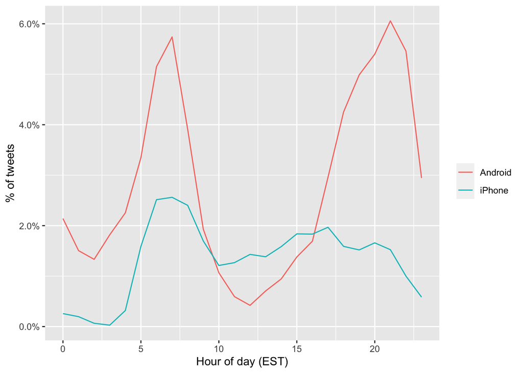

```r
cleaned_tweets %>%
  count(source, hour = hour(with_tz(created_at, "EST"))) %>%
  mutate(percent = n/sum(n)) %>%
  ggplot(aes(x = hour, y = percent, color = source)) +
  labs(x = "Hour of day (EST)", y = "% of tweets", color = "") +
  scale_y_continuous(labels = percent_format()) +
  geom_line()
```

Interpretation:

From Android, there is a lot of tweets coming at 6AM and 9PM, whereas the iPhone tweets are less concentrated at a certain time.

How often does Trump use quotes in his tweets whether the phone is an iPhone or an Android

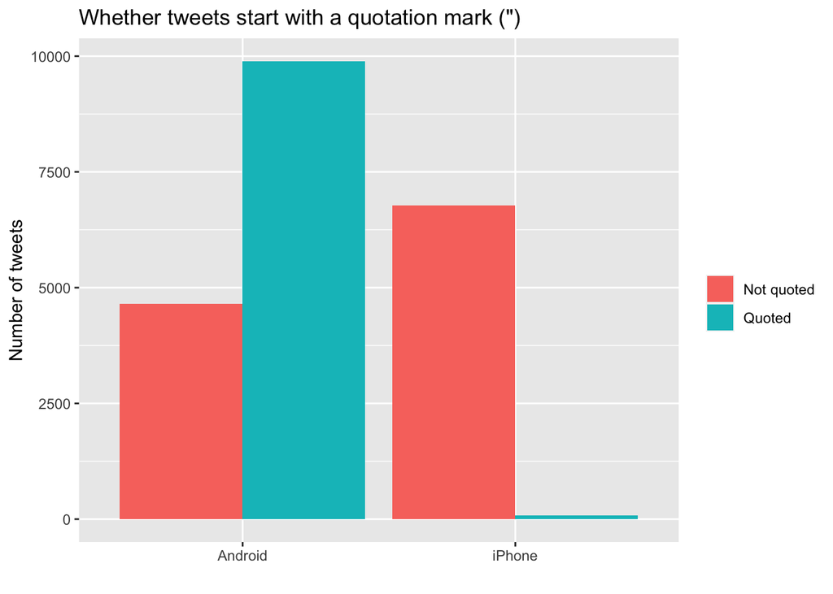

```r
cleaned_tweets %>%
  count(source,
        quoted = ifelse(str_detect(text, '^"'), "Quoted", "Not quoted")) %>%
  ggplot(aes(x = source, y = n, fill = quoted)) +
  geom_bar(stat = "identity", position = "dodge") +
  labs(x = "", y = "Number of tweets", fill = "") +
  ggtitle('Whether tweets start with a quotation mark (")')
```

Interpretation:

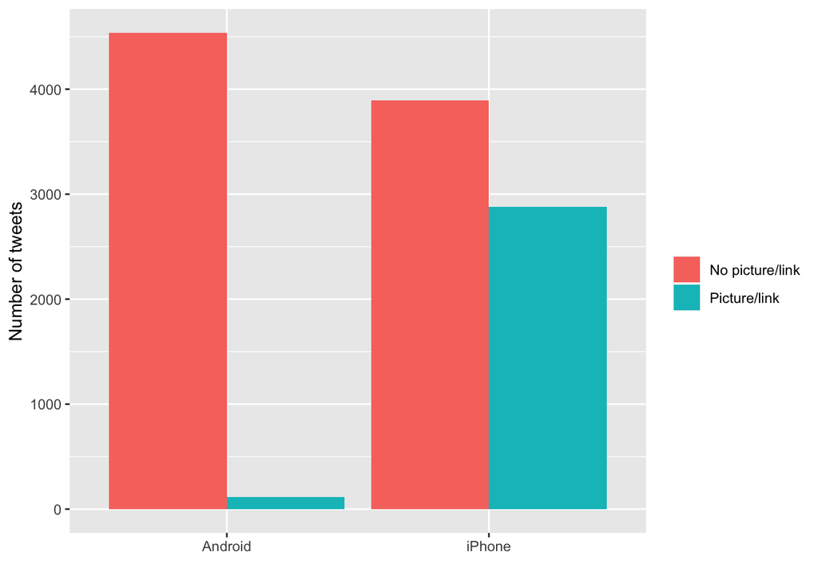

```r
#  Count the number of tweets with and without picture/links by device
tweet_picture_counts <- cleaned_tweets %>%
  filter(!str_detect(text, '^"')) %>%
  count(source,
        picture = ifelse(str_detect(text, "t.co"), # "t.co" is observable in a tweet referencing to a photo
                         "Picture/link", "No picture/link"))

# Make a bar plot
ggplot(tweet_picture_counts, aes(x = source, y = n, fill = picture)) +
  geom_bar(stat = "identity", position = "dodge") +
  labs(x = "", y = "Number of tweets", fill = "")
```

Interpretation:

The vast majority of tweets coming from the Android phone do not have pictures, whereas numerous iPhone tweets have pictures. This might suggest that the iPhone using staff is more likely to use his photos.

- Tokenizing to analyse the sentiment of the words
- Creating the regex pattern: identify words starting and ending with a letter (thus getting rid of numbers and links)
- Online link to try regex pattern: www.regexr.com
- Using the command unnest_token(): converting the strings from sentences into individual words
- Filtering out the STOP words

```r
# Load the tidytext package
library(tidytext)

# Create a regex pattern
reg <- "([^A-Za-z\\d#@]|'(?![A-Za-z\\d#@]))"

# Unnest the text strings into a data frame of words
tweet_words <- cleaned_tweets %>%
  filter(!str_detect(text, '^"')) %>%
  mutate(text = str_replace_all(text, "https://t.co/[A-Za-z\\d]+|&amp;", "")) %>%
  unnest_tokens(word, text, token = "regex", pattern = reg) %>%
  filter(!word %in% stop_words$word,
         str_detect(word, "[a-z]"))

# Inspect the first six rows of tweet_words
head(tweet_words)
```

```
## # A tibble: 6 x 4
##    id_str source created_at          word
##     <dbl> <chr>  <dttm>              <chr>
## 1 2.78e17 iPhone 2012-12-11 01:20:01 luck
## 2 2.78e17 iPhone 2012-12-11 01:20:01 bob
## 3 2.78e17 iPhone 2012-12-11 01:20:01 kraft
## 4 2.78e17 iPhone 2012-12-11 01:20:01 tom
## 5 2.78e17 iPhone 2012-12-11 01:20:01 brady
## 6 2.78e17 iPhone 2012-12-11 01:20:01 coach
```

Plotting the most common words from @realDonaldTrump tweets

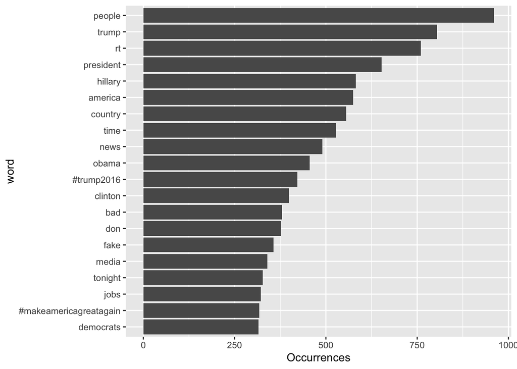

```r
tweet_words %>%
  count(word, sort = TRUE) %>%
  head(20) %>%
  mutate(word = reorder(word, n)) %>%
  ggplot(aes(x = word, y = n)) +
  geom_bar(stat = "identity") +
  ylab("Occurrences") +
  coord_flip()
```

Linking a sentiment to each of the words

```r
# Join the NRC lexicon to the
android_iphone_sentiment <-
 inner_join(tweet_words, nrc, by = "word") %>%
            group_by(sentiment)  %>%
            head(10)


# Inspect the first six rows
head(android_iphone_sentiment)
```

```
## # A tibble: 6 x 5
## # Groups:   sentiment [5]
##    id_str source  created_at          word  sentiment
##     <dbl> <chr>   <dttm>              <chr> <chr>
## 1 2.78e17 iPhone  2012-12-11 01:20:01 luck  anticipation
## 2 2.78e17 iPhone  2012-12-11 01:20:01 luck  joy
## 3 2.78e17 iPhone  2012-12-11 01:20:01 luck  positive
## 4 2.78e17 iPhone  2012-12-11 01:20:01 luck  surprise
## 5 2.78e17 iPhone  2012-12-11 01:20:01 coach trust
## 6 4.18e17 Android 2013-12-31 22:21:51 happy anticipation
```

Calculating the ratio of the words - Working with a logarithmic scales -by definition- requires non-zero number - In case if a word is mentioned on the Android, but has never been mentioned on the iPhone, or vice versa - Laplace transformation: Adding 1 to zeros and calculate ratios

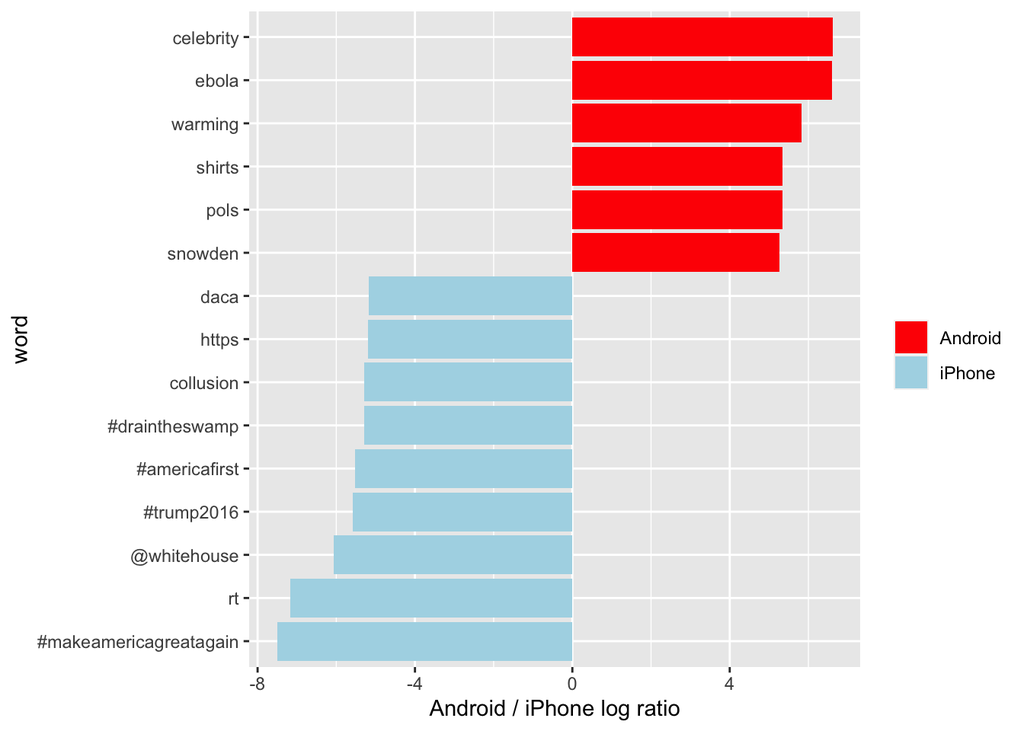

```r
android_iphone_ratios <- tweet_words %>%
  count(word, source) %>%
  group_by(word)  %>%
  filter(sum(n) >= 5) %>%
  spread(source, n, fill = 0) %>%
  ungroup()  %>%
  mutate_if(is.numeric, ~((. + 1) / sum(. + 1))) %>%
  mutate(logratio = log2(Android / iPhone)) %>%
  arrange(desc(logratio))

android_iphone_ratios %>%
  top_n(15, abs(logratio)) %>%
  ungroup() %>%
  mutate(word = reorder(word, logratio)) %>%
  ggplot(aes(x = word, y = logratio, fill = logratio < 0)) +
  geom_bar(stat = "identity") +
  coord_flip() +
  ylab("Android / iPhone log ratio") +
  scale_fill_manual(name = "", labels = c("Android", "iPhone"),
                    values = c("red", "lightblue"))
```

Interpretation:

The iPhone tweets use a lot of #s and refer to the white house, whereas the Android tweets focus on words, such as ebola, which had been a frequent topic before Trump was elected President, thus this graph also conflates tweets created before-, and after his presidency.

Solving with filtering the created_at column with the date of the announcement of running for presidency:

```r
tweets_post_announcement <- tweets %>%
  filter(created_at >= "2015-07-01")
```

```r
cleaned_tweets_post_announcement <- tweets_post_announcement %>%
select(id_str, source, text, created_at) %>%
  filter(source %in% c("Twitter for iPhone", "Twitter for Android"))  %>%
  extract(source, "source", "(\\w+)$")
```

```r
# Create a regex pattern
reg <- "([^A-Za-z\\d#@]|'(?![A-Za-z\\d#@]))"

# Unnest the text strings into a data frame of words
tweet_words_post_announcement <- cleaned_tweets_post_announcement %>%
  filter(!str_detect(text, '^"')) %>%
  mutate(text = str_replace_all(text, "https://t.co/[A-Za-z\\d]+|&amp;", "")) %>%
  unnest_tokens(word, text, token = "regex", pattern = reg) %>%
  filter(!word %in% stop_words$word,
         str_detect(word, "[a-z]"))

# Inspect the first six rows of tweet_words_post_announcement
head(tweet_words_post_announcement)
```

```
## # A tibble: 6 x 4
##    id_str source  created_at          word
##     <dbl> <chr>   <dttm>              <chr>
## 1 6.83e17 Android 2015-12-31 23:21:49 happy
## 2 6.83e17 Android 2015-12-31 23:21:49 healthy
## 3 6.83e17 Android 2015-12-31 23:21:49 finally
## 4 6.83e17 Android 2015-12-31 23:21:49 america
## 5 6.83e17 Android 2015-12-31 23:21:49 safe
## 6 6.83e17 Android 2015-12-31 23:11:35 department
```

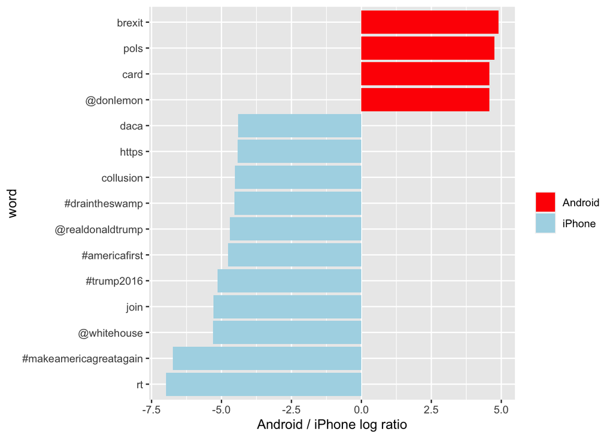

| Continue working with the filtered dataset (tweets after the announcement) |
| --- |

```r
android_iphone_ratios_post_announcement <- tweet_words_post_announcement %>%
  count(word, source) %>%
  group_by(word)  %>%
  filter(sum(n) >= 5) %>%
  spread(source, n, fill = 0) %>%
  ungroup()  %>%
  mutate_if(is.numeric, ~((. + 1) / sum(. + 1))) %>%
  mutate(logratio = log2(Android / iPhone)) %>%
  arrange(desc(logratio))

android_iphone_ratios_post_announcement %>%
  top_n(15, abs(logratio)) %>%
  ungroup() %>%
  mutate(word = reorder(word, logratio)) %>%
  ggplot(aes(x = word, y = logratio, fill = logratio < 0)) +
  geom_bar(stat = "identity") +
  coord_flip() +
  ylab("Android / iPhone log ratio") +
  scale_fill_manual(name = "", labels = c("Android", "iPhone"),
                    values = c("red", "lightblue"))
```

Analyzing each of the sentiments

```r
android_iphone_sentiment <- android_iphone_ratios_post_announcement %>%
  inner_join(nrc, by = "word") %>%
  filter(!sentiment %in% c("positive", "negative")) %>%
  mutate(sentiment = reorder(sentiment, -logratio),
         word = reorder(word, -logratio)) %>%
  group_by(sentiment) %>%
  top_n(10, abs(logratio)) %>%
  ungroup()

# Inspect the first six rows
head(android_iphone_sentiment)
```

```
## # A tibble: 6 x 5
##   word       Android    iPhone logratio sentiment
##   <fct>        <dbl>     <dbl>    <dbl> <fct>
## 1 slaughter 0.000302 0.0000169     4.16 anger
## 2 slaughter 0.000302 0.0000169     4.16 disgust
## 3 slaughter 0.000302 0.0000169     4.16 fear
## 4 slaughter 0.000302 0.0000169     4.16 sadness
## 5 slaughter 0.000302 0.0000169     4.16 surprise
## 6 explain   0.000453 0.0000338     3.75 trust
```

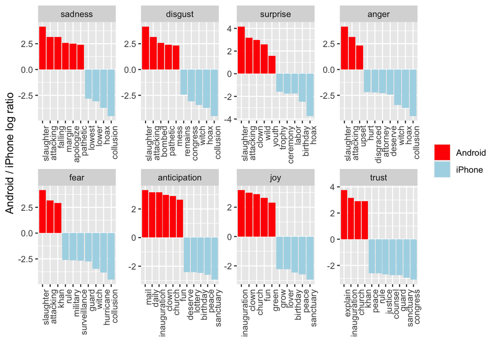

```r
# Plot the log odds ratio of words by device in groups sentiments
ggplot(android_iphone_sentiment, aes(x = word, y = logratio, fill = logratio < 0)) +
  facet_wrap(~ sentiment, scales = "free", nrow = 2) +
  geom_bar(stat = "identity") +
  theme(axis.text.x = element_text(angle = 90, hjust = 1)) +
  labs(x = "", y = "Android / iPhone log ratio") +
  scale_fill_manual(name = "", labels = c("Android", "iPhone"),
                    values = c("red", "lightblue"))
```

## ———————————————————————————————————

- Feature extraction: Creating new variables out of an unstructured data; this case the variables are: time of the day, quoted versus not, picture no picture, - Training a model that predicts whether the tweet comes from the Android or from int iPhone while Android and iPhone being the dependent variables along with independent variables, such as sentiments, whether there is a quote, whether there is a picture, whether it is a retweet with hashtags etc
- Developing a regression analysis to predict Android vs iPhone as a function of the aforementioned independent variables (however, it does not work well with words due to grammar, sarcasm, idioms etc, but works well with time of the day)
- Solution: when unnesting tokens, unnest couple of word at a time (might backfire)